```python
from IPython.core.display import HTML
css_file = "./example.css"
HTML(open(css_file, "r").read())
```

#apple { color: green; }

```python
import numpy as np
import matplotlib.pyplot as plt
%matplotlib inline
plt.rcParams['figure.figsize']=6,6
```

# Bezier Curves -- When you Need to Draw a Letter

We really take for granted out much our computer does for us! Anyone who uses Microsoft word - which is not everybody - takes advantage of an automatated layout engine. It does all the work for you:

- it draws the letters
- it arranges the letters into words
- it arranges the words into lines
  - breaking up words - or sentences - if necessary
- it adjusts the paragraphs and aligns them

Word does all of this with out much thining on our part -- except when it comes out wrong!

**More** http://learn.scannerlicker.net/2014/04/16/bezier-curves-and-type-design-a-tutorial/

I want to learn Bezier curves in order to draw **celtic knots**. I suspect they may come out bed, yet we have to start somewhere. If I remember correctly, Bezier curves are mentioned - in so many words - in Newton's *Principia Mathematica*, so we can check there too.

```
(2, 2, 2)
```

```
(-1, 4)
```

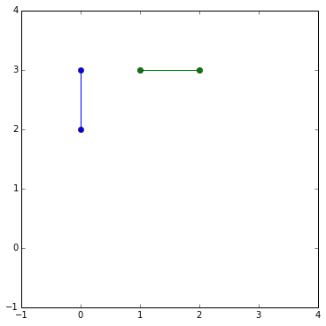

```python
lines = np.array([[[0,1],[0,2]], [[2,3], [3,3]]])

print lines.shape

# If *x* and/or *y* is 2-dimensional, then the corresponding columns will be plotted.
plt.plot(lines[0], lines[1], '-o')
plt.xlim([-1,4])
plt.ylim([-1,4])
```

```
(2, 2, 2)
```

```
(-1, 4)
```

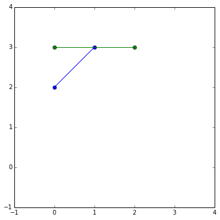

```python
lines = np.array([[[0,1],[0,2]], [[2,3], [3,3]]])

print lines.shape

# If *x* and/or *y* is 2-dimensional, then the corresponding columns will be plotted.
plt.plot(lines[0].T, lines[1].T, '-o')
plt.xlim([-1,4])
plt.ylim([-1,4])
```

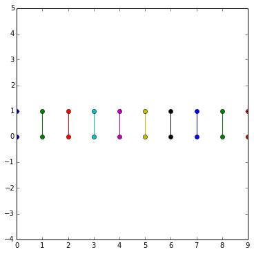

```python
# draw N vertical lines

# normally I think of a collection of lines by listing each pair of enpoints [(a0,b0), (a1,b1)]

# matplotlib expects all x coordinates together and all y coordinates together

lines = np.array([[[t,t],[0,1]] for t in range(10)])

plt.plot(lines[:,0,:].T, lines[:,1,:].T, '-o')
plt.axis("Equal")
plt.show()
```

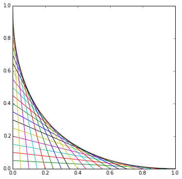

```python
dt = 0.05
t = np.arange(0,1+dt,dt)

x =  1j*t + 0*(1-t)
y =   0*t + 1*(1-t)

z = np.vstack((x,y))

plt.plot(z.real, z.imag, '-')

z = t*x + (1-t)*y
plt.plot(z.real, z.imag, '-k', linewidth=2, alpha=0.5)

plt.show()
```

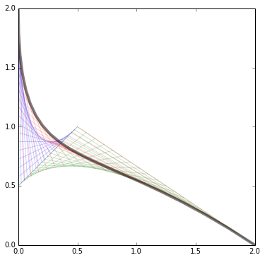

```python
x = [2j,0.5j,0.5+1j,2]

z = np.vstack((x[0]*t + x[1]*(1-t), x[1]*t + x[2]*(1-t)))
plt.plot(z.real, z.imag, '-b', alpha=0.2)

z = np.vstack((x[1]*t + x[2]*(1-t), x[2]*t + x[3]*(1-t)))
plt.plot(z.real, z.imag, '-g', alpha=0.2)

z = np.vstack((x[0]*t*t + x[1]*2*t*(1-t) + x[2]*(1-t)*(1-t), x[1]*t*t + x[2]*2*t*(1-t) + x[3]*(1-t)*(1-t)))
plt.plot(z.real, z.imag, '-r', alpha=0.2)

z = x[0]*t*t*t + x[1]*3*t*t*(1-t) + x[2]*3*t*(1-t)*(1-t) + x[3]*(1-t)*(1-t)*(1-t)
plt.plot(z.real, z.imag, '-k', alpha=0.5, linewidth=4)

plt.show()
```

# More on Bezier Curves

http://pomax.github.io/bezierinfo/ a beautiful, introductory notebook on Bézier curves on GitHub pages

[figure not shown]

emphasizes that **Bezier curves** and **Bernstein's functions** from approxmation theory are the same. He doesn't not mention the Veronese embedding, which might play a nice role here.

### TrueType Font

Going to `usr/share/fonts/truetype` we get a list of the **TrueType** fonts which are quadratic Bezier curves. We are not *designing* fonts right now, just reproducing them and learning how the letters are shaped.

[figure not shown]

Later, we will write Celtic knots and will have to find the curves for ourselves. As we see the **`ttf`** file is a *binary*, the details of this format, are not interesting to me right now... and I will install Python's `ttf` reading library.

`ttfquery` is **horrible**. I remember doing it with `fonttools` can't find it.

```python
# http://ttfquery.sourceforge.net/
# https://pypi.python.org/pypi/FontTools
import ttfquery, ttfquery.findsystem, ttfquery.describe, ttfquery.Registry
```

```
---------------------------------------------------------------------------
ImportError                               Traceback (most recent call last)
<ipython-input-10-98dc79a291fd> in <module>()
      1 # http://ttfquery.sourceforge.net/
      2 # https://pypi.python.org/pypi/FontTools
----> 3 import ttfquery, ttfquery.findsystem, ttfquery.describe, ttfquery.Registry

ImportError: No module named Registry
```

```python
ttfquery.findsystem.findFonts()
```

[output not shown]

[output cut: 144 more lines]

[output not shown]

```python
ttfquery.ttffiles.Registry()
```

```
---------------------------------------------------------------------------
AttributeError                            Traceback (most recent call last)
<ipython-input-8-0a257166b381> in <module>()
----> 1 ttfquery.ttffiles.Registry()

AttributeError: 'module' object has no attribute 'ttffiles'
```

```python
F = ttfquery.describe.family(0)
```

[output not shown]

```python
file("/usr/share/fonts/truetype/abyssinica/AbyssinicaSIL-R.ttf").read(10)
```

```
'\x00\x01\x00\x00\x00\x18\x01\x00\x00\x04'
```

# Celtic Knots - Cubic Bézier Curves

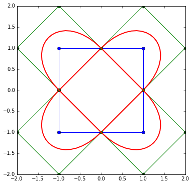

```python
z = np.array([-1-1j, -1+1j, 1+1j, 1-1j, -1-1j])

plt.plot(z.real, z.imag, 'b-o')

z = np.array([1,2+1j, 1 + 2j, 1j, -1, -2-1j, -1-2j, -1j, 1])

plt.plot(z.real, z.imag, 'g-o')

dt = 0.05
t = np.arange(0,1+dt, dt)

w = z[0]*t*t*t + z[1]*3*t**2*(1-t)**1 + 3*z[2]*t**1*(1-t)**2 + z[3]*(1-t)**3
plt.plot(w.real, w.imag, 'r-', linewidth=2)

w = z[3]*t + z[4]*(1-t)
plt.plot(w.real, w.imag, 'r-', linewidth=2)

w = z[4]*t*t*t + z[5]*3*t**2*(1-t)**1 + 3*z[6]*t**1*(1-t)**2 + z[7]*(1-t)**3
plt.plot(w.real, w.imag, 'r-', linewidth=2)

w = z[7]*t + z[0]*(1-t)
plt.plot(w.real, w.imag, 'r-', linewidth=2)

z = 1j*np.array([1,2+1j, 1 + 2j, 1j, -1, -2-1j, -1-2j, -1j, 1])

plt.plot(z.real, z.imag, 'g-o')

dt = 0.05
t = np.arange(0,1+dt, dt)

w = z[0]*t*t*t + z[1]*3*t**2*(1-t)**1 + 3*z[2]*t**1*(1-t)**2 + z[3]*(1-t)**3
plt.plot(w.real, w.imag, 'r-', linewidth=2)

w = z[3]*t + z[4]*(1-t)
plt.plot(w.real, w.imag, 'r-', linewidth=2)

w = z[4]*t*t*t + z[5]*3*t**2*(1-t)**1 + 3*z[6]*t**1*(1-t)**2 + z[7]*(1-t)**3
plt.plot(w.real, w.imag, 'r-', linewidth=2)

w = z[7]*t + z[0]*(1-t)
plt.plot(w.real, w.imag, 'r-', linewidth=2)


plt.xlim([-2,2])
plt.ylim([-2,2])
plt.show()
```

# Further Subdividing the Mesh

Realistic celtic knots need to solve more constraints than just crossing at the edges and looping around the corner. We might try to *stylize* the knot by puting tangency conditions at the corners or allow internal curving. These can be implemented using higher meshes... ultimately, these could be derived just from the graph using even higher (**4**- or even **5**- order) Bézier curves, as we might need.

What does subdivide mean? To a doctor? To your Mom? To a computer programmer? To the Walgreen's cashier?

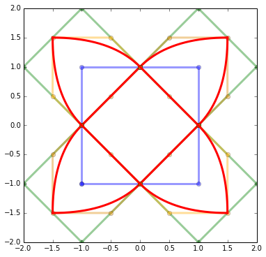

```python
z = np.array([-1-1j, -1+1j, 1+1j, 1-1j, -1-1j])
plt.plot(z.real, z.imag, 'b-o', linewidth=3, alpha=0.4)

# -------------------------------------------------------------------------

z =    np.array([1,2+1j, 1 + 2j, 1j, -1, -2-1j, -1-2j, -1j, 1])
plt.plot(z.real, z.imag, 'g-o', linewidth=3, alpha=0.4)


z = np.array([z[0], 0.5*(z[0]+z[1]), 0.5*(z[1]+z[2]), 0.5*(z[2]+z[3]), z[3], 0.5*(z[3]+z[4]),
              z[4], 0.5*(z[4]+z[5]), 0.5*(z[5]+z[6]), 0.5*(z[6]+z[7]), z[7], 0.5*(z[7]+z[0]), z[0]])
plt.plot(z.real, z.imag, '-o', color="#DD8800", linewidth=3, alpha=0.4)

w = z[0]*t**2 + 2*z[1]*t**1*(1-t)**1 + z[2]*(1-t)**2
plt.plot(w.real, w.imag, 'r-', linewidth=3)
w = z[2]*t**2 + 2*z[3]*t**1*(1-t)**1 + z[4]*(1-t)**2
plt.plot(w.real, w.imag, 'r-', linewidth=3)
w = z[4]*t**2 + 2*z[5]*t**1*(1-t)**1 + z[6]*(1-t)**2
plt.plot(w.real, w.imag, 'r-', linewidth=3)
w = z[6]*t**2 + 2*z[7]*t**1*(1-t)**1 + z[8]*(1-t)**2
plt.plot(w.real, w.imag, 'r-', linewidth=3)
w = z[8]*t**2 + 2*z[9]*t**1*(1-t)**1 + z[10]*(1-t)**2
plt.plot(w.real, w.imag, 'r-', linewidth=3)
w = z[10]*t**2 + 2*z[11]*t**1*(1-t)**1 + z[12]*(1-t)**2
plt.plot(w.real, w.imag, 'r-', linewidth=3)

# -------------------------------------------------------------------------

z = 1j*np.array([1,2+1j, 1 + 2j, 1j, -1, -2-1j, -1-2j, -1j, 1])
plt.plot(z.real, z.imag, 'g-o', linewidth=3, alpha=0.4)

z = np.array([z[0], 0.5*(z[0]+z[1]), 0.5*(z[1]+z[2]), 0.5*(z[2]+z[3]), z[3], 0.5*(z[3]+z[4]),
              z[4], 0.5*(z[4]+z[5]), 0.5*(z[5]+z[6]), 0.5*(z[6]+z[7]), z[7], 0.5*(z[7]+z[0]), z[0]])
plt.plot(z.real, z.imag, '-o', color="#FFAA00", linewidth=3, alpha=0.4)

w = z[0]*t**2 + 2*z[1]*t**1*(1-t)**1 + z[2]*(1-t)**2
plt.plot(w.real, w.imag, 'r-', linewidth=3)
w = z[2]*t**2 + 2*z[3]*t**1*(1-t)**1 + z[4]*(1-t)**2
plt.plot(w.real, w.imag, 'r-', linewidth=3)
w = z[4]*t**2 + 2*z[5]*t**1*(1-t)**1 + z[6]*(1-t)**2
plt.plot(w.real, w.imag, 'r-', linewidth=3)
w = z[6]*t**2 + 2*z[7]*t**1*(1-t)**1 + z[8]*(1-t)**2
plt.plot(w.real, w.imag, 'r-', linewidth=3)
w = z[8]*t**2 + 2*z[9]*t**1*(1-t)**1 + z[10]*(1-t)**2
plt.plot(w.real, w.imag, 'r-', linewidth=3)
w = z[10]*t**2 + 2*z[11]*t**1*(1-t)**1 + z[12]*(1-t)**2
plt.plot(w.real, w.imag, 'r-', linewidth=3)
```

# Deformation of Bezier Curves

Our Celtic knot Bezier control points can be constructed from a mesh and a dual mesh, using transformations to build more and more control points. At each place we can specify if we want a **cross** `X` or a **cup** `)(` or a **wedge** `=`. We have now found the basic curves we want, and we can elaborate even further through deformations of Bézier curves or the mesh. Once we have found our ornaments, we can turn all of these into `filters` using some basic Functional Programming in Python.